# Bayes Network

2020/3/20

## Packages

```r
package_name = c('e1071', 'klaR', 'dplyr', 'DT', 'ggplot2', 'tidyr', 'deal')
for(p in package_name) {
  if(! p %in% rownames(installed.packages())){
    cat('Try to install ', p, 'now !\n')
    tryCatch({
      install.packages(p)
    }, error = function(e) {
      print(e)
      conditionMessage(e)
    })
  }else{
    cat(p, 'has been installed !\n')
  }
}
```

```
## e1071 has been installed !
## klaR has been installed !
## dplyr has been installed !
## DT has been installed !
## ggplot2 has been installed !
## tidyr has been installed !
## deal has been installed !
```

## Library

```r
library(magrittr) # %<>%
library(dplyr) # Data Manipulation
library(tidyr) # gather and spread dataframe
library(e1071) # NaiveBayes
library(klaR) # NaiveBayes
library(DT) # Datatable
library(ggplot2) # Plot
library(deal) # Bayesian network
```

## Contingency Table

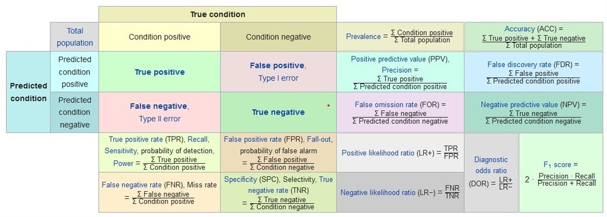

[Reference : Sensitivity and specificity](https://en.wikipedia.org/wiki/Sensitivity_and_specificity)

## Data I : Titanic

```r
data('Titanic') # Its class is table.
df_Titanic = data.frame(Titanic)
datatable(df_Titanic, options = list(pageLength = 5))
```

|  | Class | Sex | Age | Survived | Freq |
| --- | --- | --- | --- | --- | --- |
| 1 | 1st | Male | Child | No | 0 |
| 2 | 2nd | Male | Child | No | 0 |
| 3 | 3rd | Male | Child | No | 35 |
| 4 | Crew | Male | Child | No | 0 |
| 5 | 1st | Female | Child | No | 0 |
| 6 | 2nd | Female | Child | No | 0 |
| 7 | 3rd | Female | Child | No | 17 |
| 8 | Crew | Female | Child | No | 0 |
| 9 | 1st | Male | Adult | No | 118 |
| 10 | 2nd | Male | Adult | No | 154 |

[output cut: 22 more lines]

## Questions

- The factor of **Sirvived** is correlated with **Class**, **Sex**, or **Age** ?
  1. The survival probability is more in 1st class?
  2. The female survived more than the male?
  3. The children are prior to be rescued?
- Are **Class**, **Sex**, and **Age** independent variables?
- Is it possible to describe the relationship of these explanatory and explained variables?

## Raw data

```r
repeating_sequence <- rep(1:nrow(df_Titanic), df_Titanic$Freq)
rawdata <- df_Titanic[repeating_sequence,]
rawdata$Freq <- NULL # delete Freq column

nrow(df_Titanic) # Titanic is an aggregation data
```

```
## [1] 32
```

```r
nrow(rawdata)
```

```
## [1] 2201
```

## Bayes Theorem

- Explainatory : Class(F1), Sex(F2), Age(F3)
- Explained : Survived(C)

Target: find posterior prob. \(P(C|F_1,F_2, F_3)\)

Now we calculate these below with observed sample data :

1. \(\hat P(F_1,F_2, F_3)\) … sometimes we may get whole population data (evidence)
2. \(\hat P(F_1,F_2, F_3|C)\)
3. \(\hat P(C|F_1,F_2, F_3)\)
4. \(\hat P(C)\) : sometimes we may get more info about C, or let experts set a proper prior estimator

## Bayes Theorem

We have 2 ways to estimate\(P(C|F_1,F_2, F_3)\)

Plan A: Only use sample data to calc. \(\hat P(C|F_1,F_2, F_3)\)

Plan B: Use Bayesian concept \(\frac{\hat P(C) ×\hat P(F_1,F_2, F_3|C)}{\hat P(F_1,F_2, F_3)}\)

Since we dont have any prior Titanic survived info or experts’s suggestion, only relying on the sample data, the plan A may differ **little** from plan B.

## Bayesian Model

- Naive Bayes
  - Assuming the explanatory variables are **conditionally independent**.
  - [e1071::naiveBayes Source Code](https://rdrr.io/rforge/e1071/src/R/naiveBayes.R)
- Bayesian Network

  The explanatory variables are **correlated**.

## Naive Bayes Model

```r
# na.action: na.pass or na.omit

model_NaiveBayes =  naiveBayes(formula = Survived ~ .,
                               data = rawdata,
                               na.action = na.pass)

pred_NaiveBayes <- predict(model_NaiveBayes,rawdata) # predict survived
Titanic_survived <- rawdata$Survived # real survived

perform_NaiveBayes = model_performance(pred_NaiveBayes, Titanic_survived)
perform_NaiveBayes$confusion_matrix
```

```
##          true_cond
## pred_cond   No  Yes
##       No  1364  362
##       Yes  126  349
```

## NaiveBayes Performance

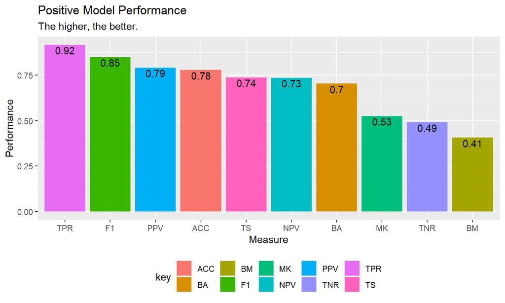

## NaiveBayes Performance

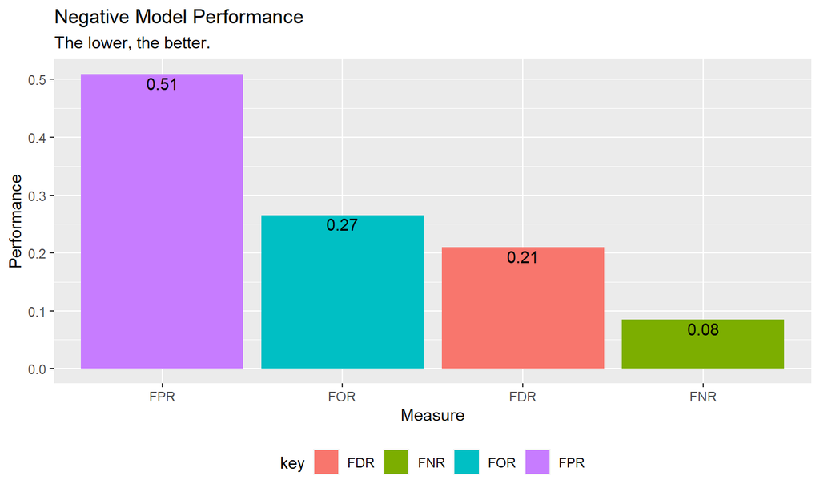

## Bayesian Network (Custom Arrow)

```r
Titanic_network <- network(rawdata)
Titanic_prior = jointprior(Titanic_network)
```

```
## Imaginary sample size: 64
```

```r
Titanic_network %<>% {getnetwork(learn(. , rawdata, Titanic_prior))}

Titanic_network %<>%
  {getnetwork(insert(. ,1, 4, rawdata, Titanic_prior))} %>%
  {getnetwork(insert(. ,2, 4, rawdata, Titanic_prior))} %>%
  {getnetwork(insert(. ,3, 4, rawdata, Titanic_prior))} %>%
  {getnetwork(insert(. ,2, 1, rawdata, Titanic_prior))} %>%
  {getnetwork(insert(. ,3, 1, rawdata, Titanic_prior))}
```

## Bayesian Network (Custom Arrow)

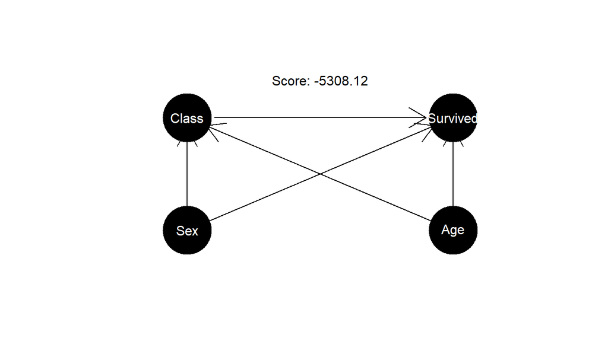

## Bayesian Network (Auto Search)

```r
Titanic_network <- network(rawdata)
Titanic_prior = jointprior(Titanic_network)
```

```
## Imaginary sample size: 64
```

```r
Titanic_network %<>% {getnetwork(learn(. , rawdata, Titanic_prior))}
```

## Bayesian Network (Auto Search)

```
## [Autosearch (1) -5646.171 [Class][Sex][Age][Survived|Sex]
## (2) -5451.297 [Class][Sex|Class][Age][Survived|Sex]
## (3) -5382.903 [Class][Sex|Class][Age][Survived|Class:Sex]
## (4) -5329.04 [Class|Age][Sex|Class][Age][Survived|Class:Sex]
## (5) -5302.627 [Class|Age][Sex|Class][Age][Survived|Class:Sex:Age]
## (6) -5292.421 [Class|Age][Sex|Class:Age][Age][Survived|Class:Sex:Age]
## (7) -5292.421 [Class|Sex:Age][Sex|Age][Age][Survived|Class:Sex:Age]
## (8) -5292.421 [Class|Sex:Age][Sex][Age|Sex][Survived|Class:Sex:Age]
## Total 0.08 add 0.01 rem 0.02 turn 0.04 sort 0 choose 0.01 rest 0 ]
```

## Bayesian Network (Auto Search)

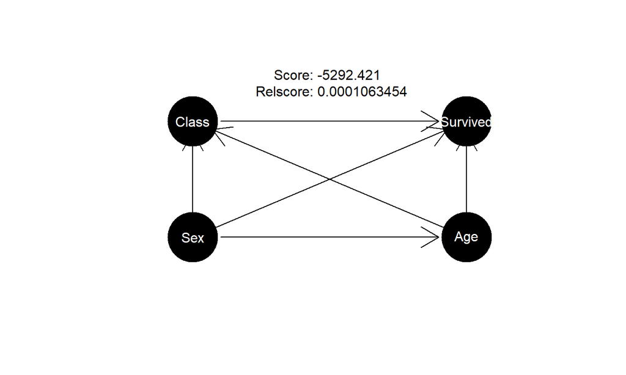